# Problem Set 05

You can access the .Rmd for the solutions [here](https://github.com/kgfitzgerald/APU_MATH_362/blob/main/PROBLEM_SETS/SOLUTIONS/PS-05-SOLUTIONS.Rmd).

## Summary / Reflection Prompts

*RP1: What were the main concepts covered in this assignment?*

*RP2: What’s one thing you understand better after completing these problems?*

*RP3: What problems gave you the most trouble? What was difficult about them/where did you get stuck?*

*RP4: What questions and/or reflections do you have regarding the Further Exploration demos and proofs?*

## Exercise 1

$$H_0: p = 0.9$$
$$H_A: p < 0.9$$

2. $\alpha = 0.01$, which corresponds to a lower-tail Z-cutoff of -2.326.

```r
qnorm(0.01)
```

```
## [1] -2.326348
```

3. Point estimate is given by $\hat{p} = \frac{460}{537} = 0.857$. Test statistic is given by $Z = \frac{\hat{p} - p_0}{\sqrt{\frac{p_0(1-p_0)}{n}}}$. Computation in code below.

```r
#value computed from sample
phat <- 460/537

#"null value" hypothesized in H0
p0 <- 0.9

#sample size
n <- 537

#test statistic
Z <- (phat - p0)/sqrt(p0*(1-p0)/n)
Z
```

```
## [1] -3.351564
```

4. Because the test statistic is more extreme (farther in left tail) than the critical value, we reject $H_0$ and conclude there is sufficient evidence to claim $p < 0.9$. The city should implement the immunization program.

## Exercise 2

The problem states “30% of the people in a random sample from a population select the right front tire”, which implies $\hat{p} = 0.3$.

### Part a

This is a sample statistic because it is the proportion observed from a sample.

### Part b

We need a sample size and an $\alpha$ level to conduct a hypothesis test

### Part c

$H_0: p = 0.25$ vs $H_0: p > 0.25$ by the context of the research question (do people disproportionately prefer the front right tire?)

### Part d

The test statistic is given by Z below

```r
#value computed from sample
phat <- .3

#"null value" hypothesized in H0
p0 <- 0.25

#sample size
n <- 100

#test statistic
Z <- (phat - p0)/sqrt(p0*(1-p0)/n)
Z
```

```
## [1] 1.154701
```

### Part e

For a right-tailed test, 0.05 corresponds to a Z-cutoff of 1.645. Recall that $Z = \frac{\hat{p} - p_0}{\sqrt{\frac{p_0(1-p_0)}{n}}}$. We can rearrange that formula to solve for $\hat{p}$.
$$\hat{p} = Z*\sqrt{\frac{p_0(1-p_0)}{n}} +
p_0$$

The code below converts Z to the scale of $\hat{p}$.

```r
Z_crit <- qnorm(.95)

phat_crit <- Z_crit*sqrt(p0*(1-p0)/n) + p0
phat_crit
```

```
## [1] 0.3212243
```

We will reject $H_0$ and claim $p > 0.25$ if $\hat{p} > 0.3212243$

### Part f

```r
#sample size
n <- 500

#test statistic
Z <- (phat - p0)/sqrt(p0*(1-p0)/n)
Z
```

```
## [1] 2.581989
```

```r
Z_crit <- qnorm(.95)

phat_crit <- Z_crit*sqrt(p0*(1-p0)/n) + p0
phat_crit
```

```
## [1] 0.2818525
```

When $n = 500$, we obtain a test statistic of 2.5819889. The critical value in this case is 0.2818525.

## Exercise 3

### Part a

The figure below shows the critical region for this test. The significance level is equal to the probability of the yellow shaded region.

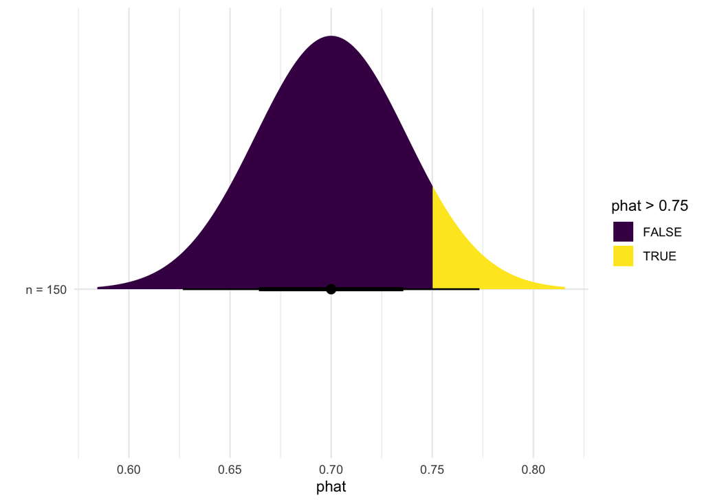

```r
library(tidyverse)
library(ggdist)
library(distributional)

n <- 150
p0 <- 0.7

ggplot() +
  stat_dist_halfeye(aes(y = "n = 150",
                        dist = dist_normal(mu = p0,
                                           sigma = sqrt(p0*(1-p0)/n)),
                        fill = stat(x > .75))) +
  labs(y = "", x = "x") +
  theme_minimal() +
  labs(x = "phat", fill = "phat > 0.75") +
  scale_fill_viridis_d()
```

Recall that we assume
$$\hat{p} \approx
N\left(p, \frac{p(1-p)}{n}\right).$$
Therefore we can find the significance level (the yellow shaded region) using the `pnorm()` function and plugging in the 0.75 cutoff value. We use `lower.tail = FALSE` because the yellow shaded region is in the upper tail.

```r
pnorm(0.75, 0.7, sqrt(.7*(1-.7)/n), lower.tail = FALSE)
```

```
## [1] 0.0907246
```

Alternatively, we could have converted $\hat{p}$ to a Z-score and found the upper tail probability of the standard normal distribution. Both methods yield the same result, as they are just algebraic manipulations of each other.

```r
phat_crit <- 0.75
Z_crit <- (phat_crit - p0)/sqrt(p0*(1-p0)/n)
Z_crit
```

```
## [1] 1.336306
```

```r
pnorm(Z_crit, lower.tail = FALSE)
```

```
## [1] 0.0907246
```

### Part b

The purple shaded region in the figure below visualizes the Type II error. That is, when $p = 0.77$ (this means $H_0: p = 0.7$ is false), and we reject if $\hat{p} > 0.75$, then the yellow shaded region results in correct decisions (reject $H_0$), whereas the purple shaded region results in incorrect decisions (fail to reject $H_0$).

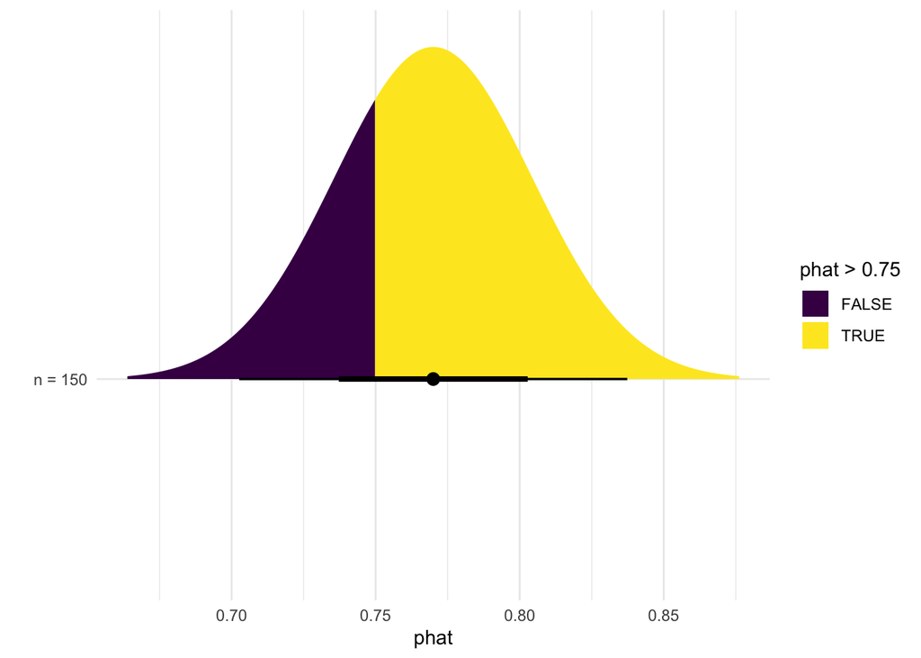

```r
p_alt <- 0.77

ggplot() +
  stat_dist_halfeye(aes(y = "n = 150",
                        dist = dist_normal(mu = p_alt,
                                           sigma = sqrt(p_alt*(1-p_alt)/n)),
                        fill = stat(x > .75))) +
  labs(y = "", x = "x") +
  theme_minimal() +
  labs(x = "phat", fill = "phat > 0.75") +
  scale_fill_viridis_d()
```

We can use the `pnorm()` function to compute this probability in R. Note the Type II error (purple) is the lower tail.

```r
pnorm(0.75, 0.77, sqrt(.77*(1-.77)/n))
```

```
## [1] 0.2802638
```

## Exercise 4

We can define a critical region $C$ such that $P(\overline{X} \in C |H_0 \text{ true}) = \alpha$ by simply rearranging $P\left(\frac{\overline{X} - \mu}{\sigma/\sqrt{n}}>z_{\alpha}\right) = \alpha$

$$\begin{aligned}
\alpha &= P\left(\frac{\overline{X} -
\mu}{\sigma/\sqrt{n}}>z_{\alpha}\right)\\
&= P(\overline{X} - \mu > z_{\alpha}\frac{\sigma}{\sqrt{n}}) \\
&= P(\overline{X}> z_{\alpha}\frac{\sigma}{\sqrt{n}} + \mu)
\end{aligned}$$

Therefore, the critical value is $c = z_{\alpha}\frac{\sigma}{\sqrt{n}} + \mu$, and the critical region can be defined as $C = \{\overline{X}:\overline{X} > c\}$.

## Exercise 5

### Part a

$$H_0: \mu = 3315$$
$$H_A: \mu < 3315$$

### Part b

The parameter of interest is a mean, so we should use the t-distribution. With a left-tailed test with $\alpha = 0.05$, we can define the critical region as
$$\overline{X} < t_{0.05, n -
1}\frac{s}{\sqrt{n}} + \mu$$

Plugging in for a sample size of $n = 30$, the critical region becomes:

```r
n <- 30
alpha <- 0.05
xbar <- 3189
s <- 488
mu <- 3315
xbar_crit <- qt(alpha, df = n - 1)*s/sqrt(n) + mu
xbar_crit
```

```
## [1] 3163.614
```

### Part c

We can compare $\overline{X} = 3189$ to our critical region above of 3163.6142341, or equivalently, compute our test statistic and compare it to $t_{0.05,29} = -1.699127$.

```r
T <- (xbar - mu)/(s/sqrt(n))
T
```

```
## [1] -1.414202
```

Because our observed value (point estimate, or test statistic) is not more extreme (farther in left tail) than the corresponding critical value, we fail to reject $H_0$. That is, there is not enough evidence to conclude birth weights in Jerusalem are lower on average than birth weights in the US.

# Simulation Exploration

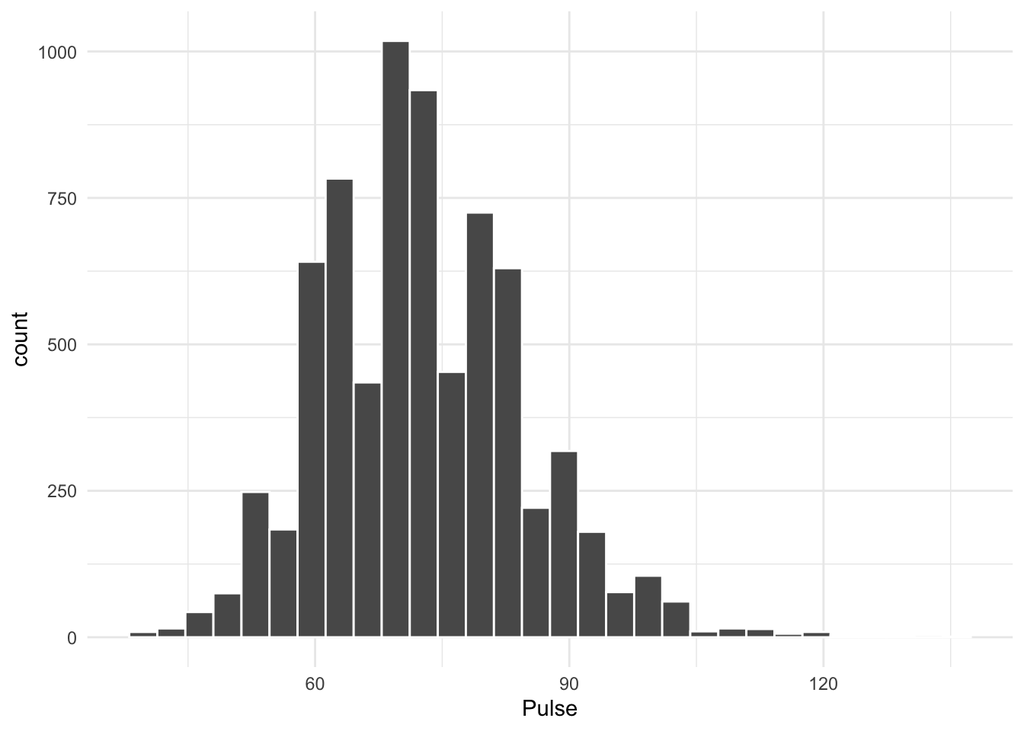

```r
library(NHANES)
library(infer)

nhanes <- NHANES %>%
  filter(!is.na(Pulse), Age >= 18)

ggplot(nhanes, aes(x = Pulse)) +
  geom_histogram(color = "white") +
  theme_minimal()
```

```r
mu <- mean(nhanes$Pulse)
```

## Exercise 6

### Part a

The null hypothesis is true in this case

### Part b

When the null hypothesis is true (as it is in this case), $T \sim t_{\alpha, n-1}$. To get an exact answer using code, we need to specify a sample size. We can use $n = 100$, which is what is used later on in the simulations.

```r
prob <- pt(1.96, 99, lower.tail = FALSE)
prob
```

```
## [1] 0.02640356
```

```r
count <- prob*10000
count
```

```
## [1] 264.0356
```

```r
prob <- pt(1.5, 99)
prob
```

```
## [1] 0.9316016
```

```r
count <- prob*10000
count
```

```
## [1] 9316.016
```

To get an approximate answer without specifying a sample size, we can recall that the t distribution and standard normal distribution are similar and use `pnorm()`.

```r
prob <- pnorm(1.96, lower.tail = FALSE)
prob
```

```
## [1] 0.0249979
```

```r
count <- prob*10000
count
```

```
## [1] 249.979
```

```r
prob <- pnorm(1.5)
prob
```

```
## [1] 0.9331928
```

```r
count <- prob*10000
count
```

```
## [1] 9331.928
```

### Part c

```r
T_crit <- qt(.975, 99)
T_crit
```

```
## [1] 1.984217
```

```r
Z_approx <- qnorm(.975)
Z_approx
```

```
## [1] 1.959964
```

For a two-sided $\alpha = 0.05$ test and a sample size of 100, we want to reject when $|T| > 1.984217$. A normal approximation can be found without specifying a sample size and yields 1.96.

### Part d

A test statistic that falls in the critical region results in rejecting $H_0$, which is an incorrect decision in this case because $H_0$ is true.

## Exercise 7

```r
n <- 100
alpha <- 0.05
mu <- mean(nhanes$Pulse)

samples <- rep_sample_n(nhanes, n,
                        replace = TRUE,
                        reps = 10000)

sample_stats <- samples %>%
  group_by(replicate) %>%
  summarize(xbar = mean(Pulse),
            s = sd(Pulse),
            T = (xbar - mu)/(s/sqrt(n)),
            T_reject = if_else((T < qt(alpha/2, n - 1) |
                                  T > qt(1-alpha/2, n - 1)), 1, 0))

sample_stats %>%
  summarize(sum(T_reject)/n())
```

```
## # A tibble: 1 × 1
##   `sum(T_reject)/n()`
##                 <dbl>
## 1              0.0519
```

We find that about 5% of the 10,000 samples lead to a test statistic that falls in the critical region, leading us to reject $H_0$ even though it is true. This is what we would expect since we set $\alpha = 0.05$

## Exercise 8

Because $\alpha = 0.05$, we will choose to reject when we obtain p-value < 0.05. The probability of finding p-value < 0.05 is equivalent to finding a test statistic that falls in the critical region. The simulations above demonstrated we expect this to happen 5% of the time (because $\alpha = 0.05$).

## Exercise 9

Exercises 7 & 8 were demonstrating Type I error: the probability of erroneously rejecting $H_0$ when it is true. If you wanted to reduce your risk of a Type I error, then you should reduce your $\alpha$, which will push your critical region farther out in the tails.